# Plotting & Spatial Relationships

Today, we’ll ease into doing some more advanced stuff using the `sf` package in `R`. The `sf` package (short for *simple features*) is the state-of-the-art package for working with spatial data `R`. It’s a *whole lot easier* to use than older packages (e.g. `rgdal` or `sp & maptools`), but there are still some interesting/confusing elements. We’ll try to take a tour of a large amount of the package, and identify a few tools or skills we’ll need going forward.

# Intermediate Simple Features in R

`sf` tries to make it so that spatial data is *not* special in `R`. Instead, it aims to make *all* the standard tools and idioms that you know how to use on *dataframes* apply to *sf* dataframes, too.[^1] This means that the `sf` package uses similar strategies to other packages, like `dplyr`, for how its dataframes work. At its most basic, this means that reading/writing spatial data works very similarly to how reading/writing non-spatial data works:

```r
library(sf)

bristol = sf::st_read('./data/bristol-imd.shp')
bristol
```

```
## Simple feature collection with 263 features and 12 fields
## geometry type:  MULTIPOLYGON
## dimension:      XY
## bbox:           xmin: 350239.4 ymin: 166638.9 xmax: 364618.1 ymax: 183052.8
## epsg (SRID):    27700
## proj4string:    +proj=tmerc +lat_0=49 +lon_0=-2 +k=0.9996012717 +x_0=400000 +y_0=-100000 +ellps=airy +towgs84=446.448,-125.157,542.06,0.15,0.247,0.842,-20.489 +units=m +no_defs
## First 10 features:
##     LSOA11CD imd_rank imd_score income employment education health crime
## 1  E01014485    11727     23.53   0.18       0.13     15.75   0.41  0.32
## 2  E01014486     2408     49.04   0.34       0.26     31.45   1.25  0.99
## 3  E01014487    16452     17.36   0.07       0.06      0.28  -0.43  0.82
## 4  E01014488    11047     24.64   0.19       0.13      4.99   0.11  1.07
## 5  E01014489     5318     37.42   0.22       0.18     10.67   0.80  1.31
## 6  E01014491    19934     13.70   0.08       0.09      1.02  -0.48  0.34
## 7  E01014492     6812     33.27   0.22       0.19     45.80   0.76  0.37
## 8  E01014493     7510     31.54   0.19       0.15     50.05   0.81  0.31
## 9  E01014494    20047     13.60   0.09       0.08     15.85  -0.18  0.49
## 10 E01014495    11742     23.51   0.13       0.13     28.23   0.63  0.40
##    housing living_env idaci idaopi                       geometry
## 1    13.84      36.20  0.18   0.30 MULTIPOLYGON (((360256.3 17...
## 2    22.07      43.52  0.39   0.57 MULTIPOLYGON (((359676 1741...
## 3    22.84      62.34  0.04   0.14 MULTIPOLYGON (((359036.6 17...
## 4    16.49      38.16  0.28   0.31 MULTIPOLYGON (((359632.6 17...
## 5    20.97      62.02  0.29   0.36 MULTIPOLYGON (((359120.6 17...
## 6    18.62      41.51  0.05   0.15 MULTIPOLYGON (((359467.6 17...
## 7    20.54      22.51  0.35   0.21 MULTIPOLYGON (((353215.9 17...
## 8    20.09      30.64  0.29   0.23 MULTIPOLYGON (((352337 1770...
## 9    13.95      20.54  0.15   0.12 MULTIPOLYGON (((352702 1767...
## 10   17.86      27.29  0.21   0.15 MULTIPOLYGON (((353137.9 17...
```

The text above describes the dataframe we just read in. It gives most of the spatial information necessary to understand the geography:

- the number of features (observations) and fields (columns) in the dataframe,
- the bounding box `bbox`,
- the type of geometry (`geometry type`) in the dataframe,
- the coordinate system (in terms of its `epsg` code as well as its `proj4` description)
- and then its rows at the end

### Check Yourself: Namespaces

“Namespaces are one honking great idea,” they say. A *namespace* is a sectioned-off area of a working environment (a *space*) where everything inside of that area is only addressable by referring to that space (by its *name*), and then to what you want that is inside of it.

Thus, something like an *address* is a great example of a namespace: BS8 1SS shows us that the `1SS` is within `BS8`, which itself is a subset of all `BS` postcodes, and all of which are within the UK (since other countries use a different postal code system).

`R` has a bit of a complex relationship with namespaces. By default, when you load a package using `library`, it dumps out everything from *within* that library. This is kind of like starting work by dumping your entire rucksack out onto your desk, then sifting through its contents every time you need something. Thus, I’ll encourage you to use `::` to be specific about *which* namespace a tool is in. When I write `sf::st_read`, this means “use the `st_read` function from within the `sf` package.” While `R` lets you use `st_read` by itself, writing `sf::st_read` is more clear, since it’s always apparent which package is being called.

### Selection & focusing plots

Since a `sf` dataframe is simply a powered-up dataframe, we can treat it like a dataframe. This includes stuff like selection, subsetting, and aggregation. For an example, the School of Geographical Sciences is located in the **L**ocal **S**uper **O**utput **A**rea with the index `E01014542`. We can grab *just* that one LSOA in a similar fashion to how we operate with other dataframes:

```r
is_geog = bristol$LSOA11CD == 'E01014542'
geog = bristol[is_geog, ]
geog
```

```
## Simple feature collection with 1 feature and 12 fields
## geometry type:  MULTIPOLYGON
## dimension:      XY
## bbox:           xmin: 357787.7 ymin: 172880.4 xmax: 358931.7 ymax: 173851.2
## epsg (SRID):    27700
## proj4string:    +proj=tmerc +lat_0=49 +lon_0=-2 +k=0.9996012717 +x_0=400000 +y_0=-100000 +ellps=airy +towgs84=446.448,-125.157,542.06,0.15,0.247,0.842,-20.489 +units=m +no_defs
##     LSOA11CD imd_rank imd_score income employment education health crime
## 55 E01014542    11034     24.66   0.04       0.03     22.01   0.67   0.9
##    housing living_env idaci idaopi                       geometry
## 55   31.76      72.08  0.04   0.36 MULTIPOLYGON (((358357.9 17...
```

Now, using the format of the data we explained above, we can see that this new `geog` dataframe has only one row. We can make a plot of this single row using the `plot` function. Let’s make a plot that highlights our `geog` LSOA on top of the rest of bristol LSOAs:

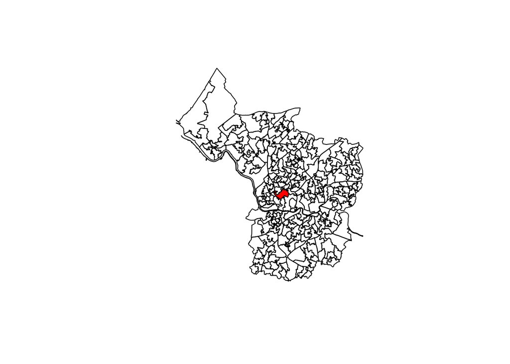

```r
# sf::st_geometry extracts *just* the geometry of the LSOA in bristol
plot(sf::st_geometry(bristol))
plot(sf::st_geometry(geog), col='red', add=TRUE)
```

It’s hard to see the LSOA in the jumble there. So, let’s zoom in on the LSOA. Part of the nice thing about using the built-in `plot` function is that it provides us with built-in `xlim` and `ylim` options we can use to focus the map. However, to pick a good focus area for the map, we could zoom in on an area that’s *near* the focal LSOA. To do this, we can: 1. buffer the LSOA, making a larger dilated polygon 2. grab the bounding box of this dilated polygon, which focuses the map on the polygon itself, but keeps a bit of the area around it, too.

To do this:

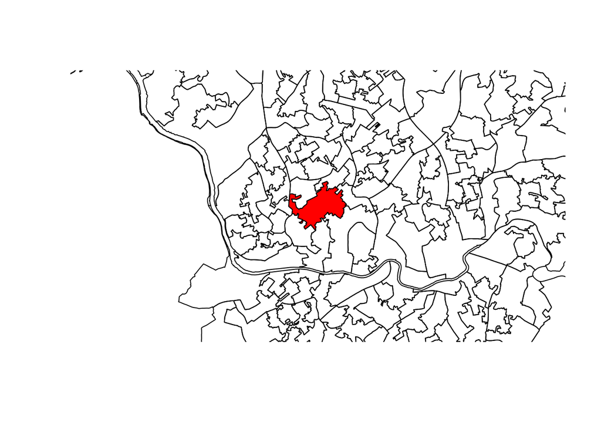

```r
buffered = sf::st_buffer(geog, 2000)
bbox = sf::st_bbox(buffered)

plot(sf::st_geometry(bristol), xlim=bbox[c('xmin','xmax')],
                               ylim=bbox[c('ymin','ymax')])
plot(sf::st_geometry(geog), col='red', add=TRUE)
```

### Exercise: Making Simple Maps

Now that you’ve seen a few things about making maps,

1. adapt the code used above to make a new map focused on each of the following points of interest in Bristol:
   - The Downs (LSOA : `E01014709`)
   - The Memorial Stadium (LSOA : `E01014510`)
   - The Centre (LSOA : `E01014540`)
   - Lakota (LSOA: `E01033348`)
   - St. Werberghs City Farm (LSOA: `E01014491`)
   - North Street (LSOA: `E01033362`)
2. `sf` makes it easy to make choropleth maps. To make a a choropleth map from a column on our dataframe, we can use the `plot` function as follows:

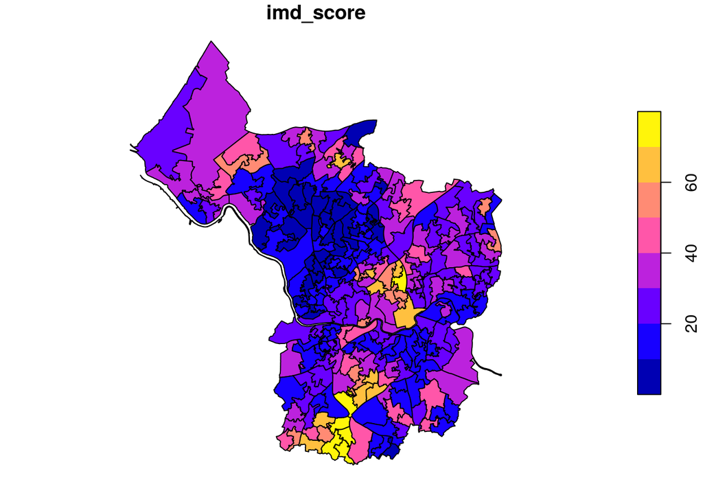

```r
plot(bristol['imd_score'])
```

with this realization,

- make a map of the `living_env` deprivation score in the area around the Downs.
- make a map of the `crime` deprivation score in the area around Lakota.
- make a map of the `housing` deprivation score in the area around The Centre.

*NOTE: Be sure to vary the buffer distance if need be.*

### Check Yourself: Classes & dispatch in R

This simple plotting works in a kind of subtle. magical way. `R` uses a system called [*multiple dispatch*](https://adv-r.hadley.nz/s4.html#s4-dispatch), which is quite complex. Basically, what is *helpful* to understand is that *most* functions in `R` decide “what to do” with their input depending on what *class* their input is.

Like… take `mean()`. If the input is a vector, the method computes the mean for that input:

```r
mean(c(2,3,7))
```

```
## [1] 4
```

However, after loading the `mosaic` library, the function can compute the mean of a `formula`, which is not a numeric argument. *Before* loading `mosaic`, however, the `mean()` function does not understand how to use formulae:

```r
unloadNamespace('mosaic') #make sure mosaic isn't loaded
mean(~imd_score, data=bristol) # this will fail
```

```
## [1] NA
```

```r
library(mosaic) #now load mosaic
mean(~imd_score, data=bristol) # and this will work
```

```
## [1] 26.95665
```

This is because the `mean` function *decides what do to* based on the class of its input. If you give it a `vector` or `numeric` argument, it’ll just compute the mean. If you give it a `formula`, the `mean` function will *do something with that* instead. But, `mean` doesn’t know how to deal with `formula` by default; it has to be enabled to use formulas by the `mosiac` package.

The same idea happens for `plot` and our spatial data. For standard `R` dataframes, `df['column']` gives you back a *dataframe*, but `df$column` gives you back the corresponding vector of values in that column. If we use `sf_df['column']`, we get back a `sf` dataframe, and plot knows how to make a choropleth map out of an `sf` dataframe with a single column. If we use `plot(sf_df$column)`, then the result just looks like a standard plot of a vector.

To check yourself, we’ll look into a few things:

- what class does `class(bristol['imd_score'])` show? and what class does `class(bristol$imd_score)` show?
- Then, look at the difference between doing something like `head(bristol['imd_score'])` and `head(bristol$imd_score)`. How do they look different?
- Now, run `plot(bristol$imd_score)`. See that it gives a very different result from `plot(bristol['imd_score'])`?
- Try to use `lattice::histogram(bristol['imd_score'])`, and then try `lattice::histogram(bristol$imd_score)`. From our test of `histogram`, do you think that `lattice` knows how to use `sf` objects?

# Spatial Relationships

Spatial *relationships* are the structural/geographical relationships between observations in a dataset. You’ve worked a little bit with spatial relationships before, especially in your group projects. However, we can compute a *large variety* of spatial relationships using `sf`. One main conceptual model of how geographical objects can relate to one another is called the *dimensionally-extended 9 intersection model*, or [DE9-IM](https://en.wikipedia.org/wiki/DE-9IM) for short. The DE9-IM, developed by Egenhofer & Franzosa (1991) to describe point set relations, is a standard model of how geographic data is represented. is shown below for two shapes, A and B:

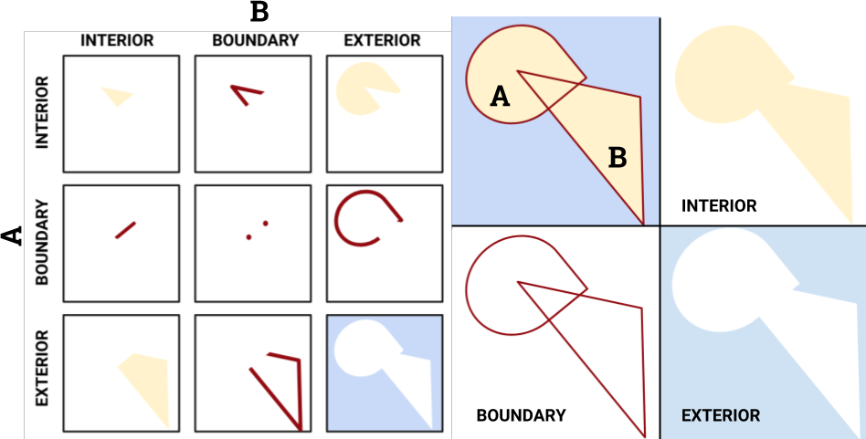

A few definitions are helpful to precisely define this idea:

1. A *point set* is a collection of points in two dimensions. Points, by definition, have no width or height, and so represent a single abstract position in space.
2. A *geometry*, or *shape*, is a collection of points. All geometries have three parts, which are their own distinct *point sets*:
   - the *interior* of a shape is the set of points where every adjacent point is also an interior point.[^2]
   - the *exterior* of a shape is the set of points where every adjacent point is also an exterior point.
   - the *boundary* of a shape is the set of points where adjacent points may be interior, exterior, or boundary points.
   - the *intersection* of set A and set B involves the set of points that are members of both A and B.

With these definitions, the DE9-IM is a system that allows us to define how geometric objects relate to one another, based on how their interiors, exteriors, and boundaries intersect with one another. Further, basic geometric objects (like points, lines, and polygons) have precise definitions of their interiors/exteriors/boundaries:

Together, this is somewhat arbitrary, but it allows us to talk about *spatial relationships* in a mathematically rigorous way. For instance, when we say that a *line crosses a polygon*, we are *formally* saying that the line’s boundary intersects the polygon’s exterior, interior, and boundary. If the *line is within a polygon*, then the line’s boundary must *not* intersect the exterior of the polygon. The full table of these relationships is somewhat complicated, but using the collection of how a geometry’s interior/exterior/boundary intersects another geometry’s interior/exterior/boundary, we can express the relationships between geographic observations.[^3]

The full table of relations is shown below:

| Name in Plain English | Description | `sf` function name |
| --- | --- | --- |
| A intersects B | Any point in A is also in B (opposite of disjoint) | `st_intersects(A,B)` |
| A is disjoint from B | No point in A is also in B (opposite of intersects) | `st_disjoint(A,B)` |
| A touches B | A point on A’s boundary touches a point on B’s boundary | `st_touches(A,B)` |
| A crosses B | A’s interior intersects B’s interior, and A’s exterior does not intersect B’s interior | `st_crosses(A,B)` |
| A is within B | A’s exterior intersects B’s interior, and A’s interior does not intersect B’s exterior (opposite of contains) | `st_within(A,B)` |
| A contains B | A’s interior intersects B’s exterior, and B’s interior does not intersect A’s exterior (opposite of within) | `st_contains(A,B)` |
| A overlaps B | A’s interior intersects B’s interior, and A’s interior intersects B’s exterior. | `st_overlaps(A,B)` |
| A covers B | All of B’s interior intersects A’s interior (opposite of covered-by) | `st_covers(A,B)` |
| A is covered by B | All of A’s interior intersects B’s interior (opposite of covers) | `st_covered_by(A,B)` |
| A equals B | Every point in A is also in B, and every point in B is also in A. | `st_equals_exact(A,B)` |

These relations are “fundamental” in the sense that they describe a *topology* for geography. A *topology* is a formal mathematical representation of the relationships between objects in a set; most of the relationships you encounter in geographical analysis are fundamentally *topological* relationships.[^4]

### Building Spatial Relationships

One of the most common, fundamental, and thoroughly-used relations is touching. `sf` makes it very fast to find out who’s touching, and where. To collect the LSOAs that touch the School of Geography’s LSOA, we can use the `st_touches` operator:

```r
nearby_touches = sf::st_touches(bristol, geog)
```

However, by default, `st_touches(a,b)` takes two spatial data frames of *many* geometries; our result, `nearby_touches`, is expressed in terms of a *matrix* of relationships between all the LSOAs in `bristol` and all the geometries in `geog`. This is expressed as a special kind of matrix. It has $n$ rows, where $n$ is the number of LSOAs in `bristol`, and $k$ columns, where $k$ is the number of geometries in `geog`. We know, however, that there is only *one* geometry in `geog`, but `sf` gives us back a full matrix anyway. So, for us to simply get back the $n$-length vector of `TRUE`/`FALSE` describing whether a geometry touches `geog`, we need to use the `apply` function.

`apply` takes a matrix, a *margin*, and a function. A margin is kind of like the *direction* the function will be used. If we supply a margin of *1*, the function will be computed over all the *rows* of the input matrix. If the margin is *2*, then the function will be applied *down the columns* of the input matrix. We just want to know if *any* observation in `bristol` touches `geog`, so we’ll use the `any` function. And, since we only have *one* column, this gives us back an $n$ length vector which is `TRUE` when that row of `bristol` touches `geog`, and is `FALSE` when that row of `bristol` does *not* touch `geog`.

```r
nearby_touches = apply(nearby_touches, 1, any)
head(nearby_touches)
```

```
## [1] FALSE FALSE FALSE FALSE FALSE FALSE
```

### Check Yourself: Recalling skills about binary vectors

How many LSOAs touch `geog`?[^5]

Now that we have the `TRUE`/`FALSE` for the geometries that touch `geog`, we can make a map of *just* the observations that touch `geog` using the standard subsetting methods you already know about:

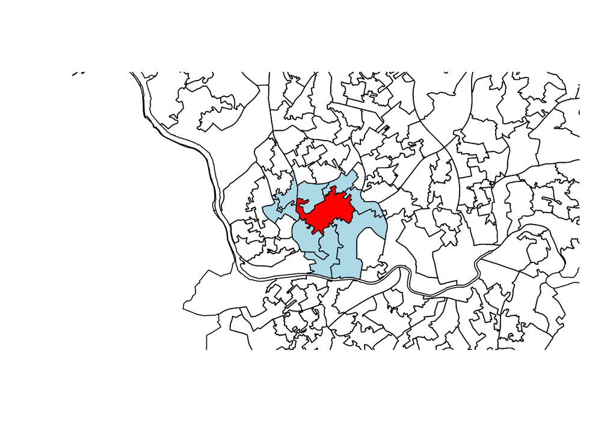

```r
plot(sf::st_geometry(bristol), xlim=bbox[c('xmin','xmax')],
                               ylim=bbox[c('ymin','ymax')])
plot(sf::st_geometry(bristol[nearby_touches,]),
     col='lightblue', add=TRUE)
plot(sf::st_geometry(geog), col='red', add=TRUE)
```

### Check Yourself: Recalling skills about inverting binary vectors

How could you make the same map, but color in the observations *not* touching `geog`?[^6]

### Composite Spatial Operations

Sometimes, you want something a little more than a *primitive* spatial operation like those defined in the table above. Like, sometimes you may want to *string together* a few spatial operations. For instance, what if we wanted to get all of the LSOAs within 500 meters of `geog`? Well, breaking our query down:

```
    LSOAs within 500 meters of geog
```

We see that there is a `within` statement, so we probably need a `within` relation. But, we want to apply a kind of *distance* filter; within 500 meters of geog. Fortunately, we can do that with tools you’ve already seen: `st_buffer`. We can build a 500-meter *buffer* around `geog`, which is our `search_area`. Then, any observations that are contained within that area will be considered as within 500 feet.

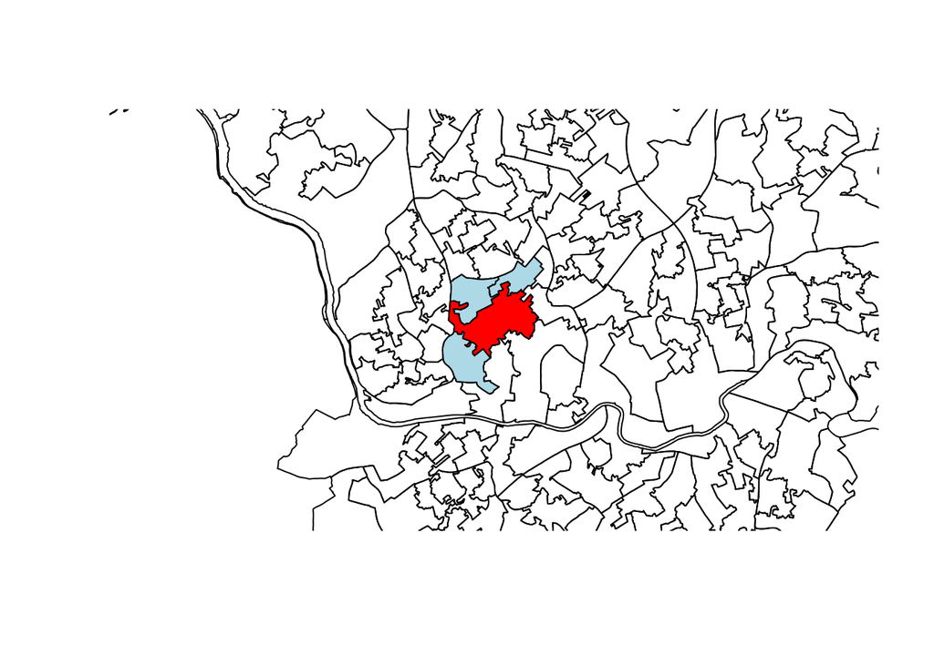

```r
search_area = st_buffer(geog, 500)
within_500m = st_within(bristol, search_area)
within_500m = apply(within_500m, 1, any)
plot(sf::st_geometry(bristol), xlim=bbox[c('xmin','xmax')],
                               ylim=bbox[c('ymin','ymax')])
plot(sf::st_geometry(bristol[within_500m,]),
     col='lightblue', add=TRUE)
plot(sf::st_geometry(geog), col='red', add=TRUE)
```

Woah! That’s fewer than that actually *touch* `geog`? This may not be what you expected, and here’s why: *human beings* commonly understand `anything within 500 meters of geog` to mean where *any part* of the area is within 500 meters of *any part* of `geog`… we have a slightly different semantics for `within` than DE9-IM.

So, thinking a little more critically about what we want, we may *instead* do something like: 1. build a search area of 500 feet around `geog` 2. select all LSOAs with any part in that search area.

For “any part in that search area”, we need to think about `intersects`, not `within`. So, using that concept of what our search query means, we do:

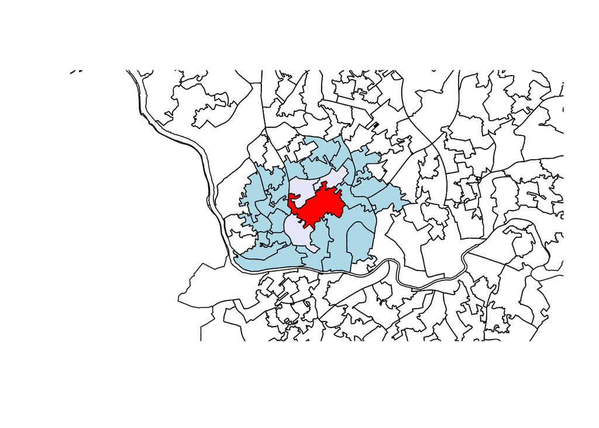

```r
nearby_within_500m = st_intersects(bristol, search_area)
nearby_within_500m = apply(nearby_within_500m, 1, any)
plot(sf::st_geometry(bristol), xlim=bbox[c('xmin','xmax')],
                               ylim=bbox[c('ymin','ymax')])
plot(sf::st_geometry(bristol[nearby_within_500m,]),
     col='lightblue', add=TRUE)
plot(sf::st_geometry(bristol[within_500m,]),
     col='lavender', add=TRUE)
plot(sf::st_geometry(geog), col='red', add=TRUE)
```

That looks more like what folks think of when they say `anything within 500 meters`.

### Exercise: The varying density of LSOAs

For the set of interesting areas we examined before:

- The Downs (LSOA : `E01014709`)
- The Memorial Stadium (LSOA : `E01014510`)
- The Centre (LSOA : `E01014540`)
- Lakota (LSOA: `E01033348`)
- St. Werberghs City Farm (LSOA: `E01014491`)
- North Street (LSOA: `E01033362`)
1. Get the total number of observations that:
   - touch the area of interest
   - intersect a 500 meter search area around the area of interest
   - intersect a 1000 meter search area around the area of interest
   - intersect a 1500 meter search area around the area of interest
2. Which area of interest is in the most densely-packed part of Bristol?

### Challenge: Responsible to a Higher Order

```r
second_order = st_touches(bristol, bristol[nearby_touches, ])
second_order = apply(second_order, 1, any)
```

gives us the second-order neighbors of `geog`.

1. Make a map of all the observations that are second-order neighbors of `geog`. **do not** highight `geog` in red. Is there anything surprising about the second-order neighbors of `geog`?
2. Using `second_order` use the same concepts to make a map of the `third_order` and `fourth_order` neighbors. 3. For an extra-hard challenge, it’s common to say that the *$n$-th order **exclusive** neighbors* are those neighbors that *first* occur at the $n$th order. By convention, the observation itself is considered the “zeroth” order neighbor, and is always excluded from higher-order neighbors. For our `second_order` example above, we can filter out observations we’ve seen at lower orders using the *exclusive or* function, `xor`, and the `OR` operator, `|`:

```r
second_order_exclusive = xor(second_order, nearby_touches | is_geog)
```

In this, we want to get the elements that are `TRUE` *only* in `second_order` and not in either `nearby_touches` or `is_geog`. Extending this idea,

- make a plot of the `nearby_touches` and `second_order_exclusive` neighbors.
- following the same pattern above, compute `third_order_exclusive` and `fourth_order_exclusive`.
- Make a map of all of the exclusive neighbors together in a single image, with different colors for each level of exclusive neighbor.

### Kernels and Distances in `sf`

The last major kind of spatial relationships tends to focus on *distances*. But, instead of focuing on *continuous* functions of distance, a *kernel* function is a smoothly-varying expression of how close two observations are. *Kernel* functions usually take the *distance* between observations and then express them in terms of a value between zero and one, where one means *really close* and zero means *really far*. This reflects a kind of *standardized nearness* score, and is incredibly common in machine learning, data science, and geographical analysis.

We can get the *distances* from `geog` and every other observation in bristol using `sf_distance`:

```r
distances = st_distance(bristol, geog)
```

To see all the distances, use:

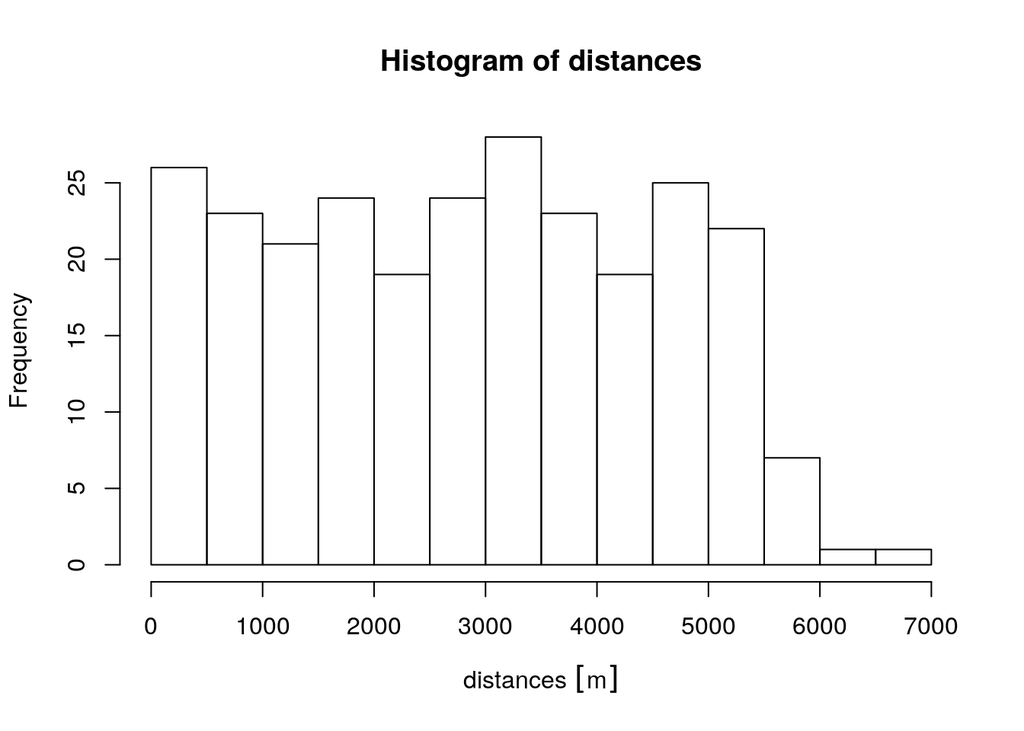

```r
# because distances have units, and lattice doesn't understand them,
# we *have* to use hist and not lattice::histogram!!
hist(distances)
```

### Check Yourself: Near and Far

Add a column to `bristol` called `distance_from_geog`. Make a choropleth map of that new column.

### Kernel functions

Now, given all these distances, we can compute a *kernel* around `geog` using the following approach:

```r
kernel = exp(-as.numeric(distances)/1500)
```

With this, we’re saying that our *nearness score* is:
$$k(i,j) = e^{\left(-\frac{d_{ij}}{1500}\right)}$$
The $1500$ value is called the *bandwidth*, and it reflects a kind of baseline level of nearness in the map. This is a *parameter* that we can tune to increase or decrease the average nearness in the map.

To visualize the kernel, you can assign a new column and make a map:

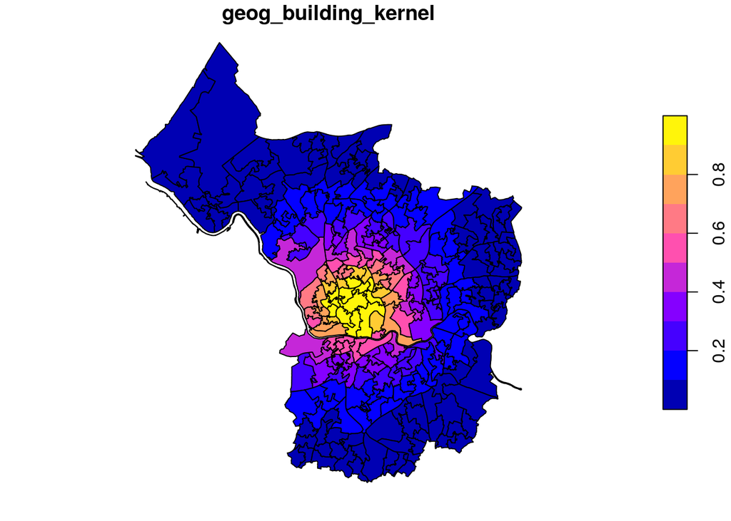

```r
bristol['geog_building_kernel'] = kernel

plot(bristol['geog_building_kernel'])
```

### Exercise: Building Kernels & Kernel Maps

1. Try repeating the kernel & plotting code above using a few different values for the *bandwidth*.
- Make a map for bandwidth values of 10, 100, 1000, and 10000. What happens to the similarity between observations as bandwidth gets really small? What about when it gets large?
2. Kernel functions abound. Pick a kernel function listed on wikipedia and define it as a function in R.[^7] For example, the negative exponential kernel we used above would be defined as:

```r
nexp_kernel = function(distance, bandwidth=1500){
                       u = as.numeric(distance) / bandwidth
                      return(exp(-u))
                      }
```

In general, the kernel function defines `u = distance / bandwidth`, and then uses the equations you see online as standard kernel shapes. So, for one more example, we could implement the sigmoid kernel as:

```r
sigmoid_kernel = function(distance, bandwidth=1500){
                          u = distance/bandwidth
                          return( (2 / pi) * (1/(exp(u) + exp(-u))) )
                          }
```

Then, make a map of the kernel using the same bandwidths you did in part 1.

- How does the map change as bandwidth changes for the kernel function you picked?
- How is the map of kernel weights you picked different from the negative exponential kernel you tried in part 1?

# Spatial Lags

Now, we can talk about how spatial relationships help us talk about *spatial relateness* and *spatial similarity*. Since we now know how to use DE9-IM language to define spatial relationships, we can just assume that we’ve picked *some* method of defining observations that are *nearby* and some that are not. Moving a bit more abstract, let’s move away from `geog`, and call it just *any* site, $i$, with an observed value for some data $x$, called $x_i$. Then, let some other observations, $j$, be found in our spatial search nearby $i$. For now, let’s call the collection of these observations the *neighborhood* of site $i$, and let’s spell that in Greek as $\eta_i$. Then, for every observation in the neighborhood of `geog` (which is spelled $j \in \eta_i$ in mathematical language), we observe data at the other sites $j$ and call them $x_j$.

If we wanted to *summarize* the values $x_j$ for $j$ in the neighborhood of $i$, one common method is the *local sum*. This measure adds up all $x_j$ for $j \in \eta$:
$$\boldsymbol{l}_i = \sum_{j\in\eta_i} x_j$$
Breaking this expression down, we see that the local sum for observation $i$ is the sum of all of the features in the neighborhood around $i$. For some other observation, the neighborhood will be different, as will the local sum. In addition, if we change what $\eta_i$ is *made of*, like by changing from first-order to second-order neighbors, or from a very narrow/small bandwidth to a wide/large bandwidth, we will change the local sum.

The local sum is useful when we need the *count* of something nearby $i$. This might make sense when you’re interested only in the total number of things in the neighborhood, like “I aced that SM2 test, how many pubs are within a 100-meter radius of Wills?” But, this does *not* give us a summary of what nearby areas are like *individually*. Instead, we might want to know the *average*, *median*, or *standard deviation* for all $x_j$ in the neighborhood of $i$. For the data we’ve been working with on the Bristol index of multiple deprivation, the local average is a useful statistic, since it gives us a *single score* for the deprivation *surroudning* `geog` that can be compared to the deprivation at `geog` itself. Thus, *local weighted averages* are the most common form of summary by far:
$$\boldsymbol{l}_i = \frac{1}{n_{\eta_i}}\sum_{j \in eta_i} w_{ij}x_j$$
where $n_{\eta_i}$ is the number of observations in $i$’s neighborhood and $w_{ij}$ is the weight relating sites $i$ and $j$. For some kinds of spatial relationships, $w_{ij}$ is only zero or one, such as when we used `st_touches(bristol, geog)`: there, $w_{ij}$ is `TRUE` (or $1$) when row $j$ of `bristol` touches `geog`, and is zero when they do not touch. Alternatively, $w_{ij}$ can be some continuous value expressing the geographcial nearness between sites $i$ and $j$, like the kernel functions we used before. Regardless, this kind of local weighted sum is *the most common* way of summarizing the surroundings of an observation.[^8] As a matter of terminology, this *local weighted sum* for variable $x$, when it’s taken for *every site* instead of just at a single site, is usually called the *spatial lag* of $x$, and likewise we’d refer to the *spatial lag around $i$* as the *local weighted sum* for site $i$.

To actually compute these values, we can do something similar to what we did before. 1. split the dataframe according to observations being *in* our spatial search area 2. summarize the observations that are within our spatial search area using an appropriate function

Below, we can use our `nearby_touches` vector to extract only the rows of `bristol` that touch `geog`:

```r
bristol[nearby_touches, ]
```

```
## Simple feature collection with 8 features and 13 fields
## geometry type:  MULTIPOLYGON
## dimension:      XY
## bbox:           xmin: 357138.7 ymin: 172034.8 xmax: 359550.4 ymax: 174170.8
## epsg (SRID):    27700
## proj4string:    +proj=tmerc +lat_0=49 +lon_0=-2 +k=0.9996012717 +x_0=400000 +y_0=-100000 +ellps=airy +towgs84=446.448,-125.157,542.06,0.15,0.247,0.842,-20.489 +units=m +no_defs
##      LSOA11CD imd_rank imd_score income employment education health crime
## 52  E01014538    22829     11.15   0.03       0.01      0.48  -0.27 -0.04
## 53  E01014539    19569     14.06   0.07       0.06      0.38  -0.58  0.78
## 54  E01014540     9221     27.91   0.12       0.08     18.87   0.23  1.36
## 63  E01014551    20037     13.61   0.04       0.03      7.13  -0.18  0.14
## 66  E01014554    22105     11.74   0.03       0.03      5.02  -0.54  0.81
## 245 E01033342    10818     25.08   0.07       0.05     19.11   0.53  1.02
## 246 E01033344     8994     28.33   0.11       0.07      7.90   0.27  1.37
## 247 E01033345    14154     20.11   0.02       0.01      7.15  -0.59  1.45
```

[output cut: 18 more lines]

and, if we wanted the average of the `imd_score` from within that subset, we could grab the mean from the `imd_score` column of that new subsetted data:

```r
mean(bristol[nearby_touches, ]$imd_score)
```

```
## [1] 18.99875
```

### Exercise: Computing Spatial Lags

1. Compute the overall/global average of `bristol$imd_score`.
2. Compute the local average around `geog` using `nearby_within_500m`.
- What is the local average around `geog`?
- Is that larger or smaller than the global average?
- Is that larger or smaller than the local average found using `nearby_touches`?
- Given that we’ve seen that `nearby_touches` includes fewer, closer observations than `nearby_within_500m`, how do you *geographically* interpret the fact that one has a higher deprivation score than another?
2. The function `weighted.mean` allows you to take a weighted mean in `R`. Using `weighted.mean`:
- Compute the weighted mean of `bristol$imd_score` using `kernel` as the weights. Is this larger or smaller than the local weighted average from `nearby_touches`?
- Change the bandwidth to be very small. Does the local weighted average increase or decrease?
- Change the bandwidth to be very large. How does that affect the local weighted average? Does it approach the map average?
- Compute the weighted mean of `bristol$imd_score` using `nearby_touches` as the weights vector. Is this the same as the local weighted average around $i$? Using the equation for the local weighted mean above, why does `nearby_touches` work this way?

### Challenge: Thinking About Spatial Dependence

1. For the areas of interest we used above:
   - The Downs (LSOA : `E01014709`)
   - The Memorial Stadium (LSOA : `E01014510`)
   - The Centre (LSOA : `E01014540`)
   - Lakota (LSOA: `E01033348`)
   - St. Werberghs City Farm (LSOA: `E01014491`)
   - North Street (LSOA: `E01033362`)

Compute the local average of observations that touch each area of interest.

2. Make a dataframe[^9] for all the areas of interest *and* `geog` containing:
   - one column of the `lsoa_id` for that row
   - one column of the *focal* value for `imd_score` (i.e. the value of `imd_score` in that area of interest)
   - one column of the *spatial lag* value for `imd_score` (i.e. the local weighted average of `imd_score` in that area of interest)
3. Compute the raw correlation between those two columns using `cor`. Disregarding any statistical significance (for now), is the relationship between those sites and their surroundings positive or negative? Put another way, are the surroundings of those sites *similar to* or *dissimilar to* the areas of interest themselves?

# Conclusion

Spatial relationships are fundamental to quantitative geography. In abstract, we need to represent geographical structures in ways that we can *use* when we build models. Above, We’ve seen many different ways that spatial relationships are represented in mathematical or computational structures. We’ve also seen how we can use these structures to summarize the *local* structure of a map in a mathematical way; instead of simply computing statistics about the map as a whole, we can build *local averages* or *local sums* that describe the structure of a map *around an area of interest*. This is a very common idea in quantitative geography, and helps us do a lot of different, neat things.

Beyond *quantitative* geography, Geographical Information Science also focuses extensively on spatial relationships. The Dimensionally Extended 9-Intersection Model we discussed is a bedrock of GIS; the idea of the spatial *predicate* is a fundamental component of working with spatial databases and understanding or expressing spatial relationships. Despite the fact that these relationships have been *formalized*, however, we’ve also now seen how these may not *exactly* reflect the spatial relationship that springs to mind when the technical term (e.g. `within`) is used. Overall, this means that it is important to understand both what the *formal* meaning of a predicate is, and it reinforces that you need to be *very clear and precise* in your thinking when discussing spatial relationships. Like any formal language (e.g. mathematics, programming langauges), the formal language of *spatial relationships* can be difficult to speak correctly the first time, so be sure to play around with it so that you can get it right.

Finally, we’ll move forward by seeing the ways in which geographcial structures can be used to estimate spatial statistics and characterize the strength and direction of *spatial* relationships. This will *extensively* use `sf` and the ideas covered in this notebook, so please do be sure to review the concepts behind the local weighted average.

# Notes

[^1]: This is a *critical* idea in system design, and even has its own fancy [Russian-sounding theorem](https://en.wikipedia.org/wiki/Liskov_substitution_principle). Put a little more simply, this reduces to: special cases should not be special enough to break the rules.
[^2]: A clever student might think this is a reprisal of Zeno’s [Dichotomy Paradox](https://en.wikipedia.org/wiki/Zeno%27s_paradoxes#Paradoxes_of_motion). Indeed, an [open set](https://en.wikipedia.org/wiki/Open_set) in mathematics is kind of like that… for any point $p$ that’s near the edge of the *interior*, we can always pick some really small distance $\epsilon$ so that some point $p'$ is closer to the edge of the interior, but still is inside the interior. Relocate $p$ to $p'$. Then, keep looking for another (smaller) $\epsilon$ that keeps a new $p'$ within the interior. In the limit, $\epsilon$ will get smaller and smaller. However, because $\epsilon$ can get *infinitessimally small*, we actually never have to pick a $p'$ that is outside of the interior. In a slightly more formal way, this is exactly the mathematical definition of an *open set*. A *closed* set is one where there is some $p'$ where we cannot pick $\epsilon$ so that we get closer to the edge; at that point, we either are in or we are out.
[^3]: The DE9IM only applies for *vector* data of infinite resolution; raster data is much simpler to understand and represent, since it fundamentally is a collection of regularly-sampled positions with known values. There is no *geometry* other than the grid that raster data represents. And, practically speaking, computers can only represent vector data with finite precision, so the interior/exterior of shapes is not *actually* a fully open set. But, the DE9IM is a *conceptual model* for how we’ll talk about spatial relationships between geometries.
[^4]: In case you ever want to *dress up* what you do as a quantitative geographer, you can always call yourself a mathematician studying applied topology, but folks might look at you sideways.
[^5]: How would you get the sum total of `TRUE`s in a vector? Recall that, under the hood, a *boolean* variable is represented with one for `TRUE` and zero for `FALSE`.
[^6]: In `R`, you can change `TRUE` to `FALSE` by doing `!TRUE`. Try this yourself at the console. This is because `!` is the *negation operator* in `R`, and will flip `FALSE` to `TRUE` and vice versa
[^7]: If you pick the uniform kernel from wikipedia, I won’t stop you, but I can promise it ain’t the most illuminating experience.
[^8]: But, it is definitely not the *only* way; we use this *idea* of summarizing the neighborhood of $i$ in a very general way in quantitative geography. For instance, another well-known spatial statistic we will cover soon is built from $\boldsymbol{l}_i = \frac{1}{n_{\eta_i}}\sum_{j \in \eta_i} w_{ij}(x_i - x_j)^2$, the *local dissimilarity* between $i$ and its surroundings.
[^9]: Making dataframes by ‘hand’ can be done using the `data.frame` function. For instance, if I had three areas of interest and their `lsoa_id`, `imd_score`, and `lag_imd_score`, I could do:

    ```r
    data.frame(list(
                lsoa_id = c(1, 2, 3),
                imd_score = c(20, 45, 99),
                lag_imd_score = c(22, 34, 79)
               )
    )
    ```